# Quality control and PCA of CryptoWakeup RNAseq

Edward Wallace

2022-08-31

# Summary

Quality control of CryptoWakeup RNA-seq data after read processing.

This analysis does:

- Heatmap of counts showing log-scale correlations.
- PCA plot showing how samples are similar to one another.

It concludes that :

- biological replicates are reproducible.
- principal components capture meaningful factors: growth time, medium and temperature.
- the variance structure is complex, probably due to the complex multifactorial design.

# Load and organise raw count data

## Load the raw counts

This is the output of featurecounts, one integer per gene.

```r
counts_raw <-
  here::here("results", "counts", "counts.txt") %>%
  readr::read_tsv(comment = "#",
                  col_types = "ccccciiiiiiiiiiiiiiiiiiiiiiiiiiiiiiiiiiiii")
counts_raw
```

```
## # A tibble: 8,194 × 44
##    Geneid     Chr    Start End   Strand Length CWP2_Tag14_Lall… CWP1_Tag12_Lall…
##    <chr>      <chr>  <chr> <chr> <chr>   <int>            <int>            <int>
##  1 CNAG_00002 1;1;1… 1273… 1290… +;+;+…    773                6                1
##  2 CNAG_00003 1;1;1… 1402… 1430… -;-;-…   1752               37               36
##  3 CNAG_00004 1;1;1… 1642… 1645… -;-;-…   2547              105               65
##  4 CNAG_00005 1;1    2075… 2268… -;-      2106                7                6
##  5 CNAG_00006 1;1;1… 2471… 2483… -;-;-…   1091              136               77
##  6 CNAG_00007 1;1;1… 2627… 2656… +;+;+…   1969               73               85
##  7 CNAG_00008 1;1;1… 2855… 2888… -;-;-…   3648              354              132
##  8 CNAG_00009 1;1;1… 3308… 3374… +;+;+…   1473              127               14
##  9 CNAG_00010 1;1;1… 3574… 3627… -;-;-…   3449              433               47
## 10 CNAG_00011 1;1;1… 4023… 4049… +;+;+…   1241               64               40
## # … with 8,184 more rows, and 36 more variables: CWP2_Tag08_Lall_aln.bam <int>,
## #   CWP2_Tag09_Lall_aln.bam <int>, CWP1_Unassigned_Lall_aln.bam <int>,
## #   CWP2_Tag23_Lall_aln.bam <int>, CWP1_Tag17_Lall_aln.bam <int>,
## #   CWP2_Tag27_Lall_aln.bam <int>, CWP2_Tag11_Lall_aln.bam <int>,
## #   CWP1_Tag27_Lall_aln.bam <int>, CWP1_Tag09_Lall_aln.bam <int>,
## #   CWP2_Tag20_Lall_aln.bam <int>, CWP1_Tag18_Lall_aln.bam <int>,
## #   CWP1_Tag05_Lall_aln.bam <int>, CWP2_Tag10_Lall_aln.bam <int>, …
```

## Load the sample sheet

The sample sheet describes the sample information, filenames, as well as sequence and tag names relevant to library prep.

```r
sample_sheet <-
  here::here("input", "experiment",
             "CryptoWakeUpSampleSheetPlusTagsAndRawFilenames.txt") %>%
  readr::read_tsv(comment = "#") %>%
  dplyr::mutate(BamFileName = paste(P7,
                                    TagID,
                                    unwanted_filename_string_bam,
                                    sep = "_")
  )
sample_sheet
```

```
## # A tibble: 36 × 12
##    SampleID Code  Medium Temp   Time Rep   TagID TagRead   P7    R1      R2
##    <chr>    <chr> <chr>  <chr> <dbl> <chr> <chr> <chr>     <chr> <chr>   <chr>
##  1 CW01     YM9A  YPD    30C     180 A     Tag09 CAACACTTT CWP1  CWP1_T… CWP1_T…
##  2 CW02     YC0A  YPD    25C       0 A     Tag12 CATCTGTAT CWP1  CWP1_T… CWP1_T…
##  3 CW03     YC1A  YPD    25C      10 A     Tag18 CTGGTTCAT CWP1  CWP1_T… CWP1_T…
##  4 CW04     YC2A  YPD    25C      30 A     Tag27 GGTACCGGT CWP1  CWP1_T… CWP1_T…
##  5 CW05     YC3A  YPD    25C      60 A     Tag06 AGTTAGAGT CWP1  CWP1_T… CWP1_T…
##  6 CW06     YC4A  YPD    25C     120 A     Tag25 GCGAGTTGT CWP1  CWP1_T… CWP1_T…
##  7 CW07     YH1A  YPD    37C      10 A     Tag29 GTCCATATT CWP1  CWP1_T… CWP1_T…
##  8 CW08     YH2A  YPD    37C      30 A     Tag17 CGTGGTAAT CWP1  CWP1_T… CWP1_T…
##  9 CW09     YH3A  YPD    37C      60 A     Tag16 CGCCAGACT CWP1  CWP1_T… CWP1_T…
## 10 CW10     YH4A  YPD    37C     120 A     Tag02 AAGTGCCGT CWP1  CWP1_T… CWP1_T…
## # … with 26 more rows, and 1 more variable: BamFileName <chr>
```

Next make the abbreviated sample sheet containing only the experimental design information, which is summarized in the “Code” variable that uniquely identifies each sample.

```r
sample_sheet_abbreviated <-
  sample_sheet %>%
  dplyr::select(SampleID, Code, Medium, Temp, Time, Rep)  %>%
    dplyr::mutate(MedTempTime = stringr::str_sub(Code,end = 3L),
                  MediumTemp = paste(Medium,Temp) %>%
                    replace(which(sample_sheet$Time == 0), "YPD 5days"))

Codelevels = sample_sheet$Code
```

## Organise the counts using the sample sheet

```r
counts_all <-
  counts_raw %>%
  dplyr::select(sample_sheet$BamFileName)  %>%
  magrittr::set_names(sample_sheet$Code) %>%
  magrittr::set_rownames(counts_raw$Geneid)
counts_all
```

```
## # A tibble: 8,194 × 36
##     YM9A  YC0A  YC1A  YC2A  YC3A  YC4A  YH1A  YH2A  YH3A  YH4A  RC1A  RC2A  RC3A
##  * <int> <int> <int> <int> <int> <int> <int> <int> <int> <int> <int> <int> <int>
##  1    16     1     0    31    13    12    12     3    35   130     9    60    48
##  2    11    36    21    45    80   104    17    11    53   107    42    18   100
##  3   131    65    94   120   367   349   182    45   233   453   115   315   389
##  4    18     6     0    10    79   158    39    72   334   351    13     6    15
##  5   201    77   190   198   301   285   371   169   271   628    59   299   298
##  6   107    85    73   186   319   391   337   121   351   675    44   102   129
##  7   190   132   126   370   403   729   517   280   741  1095   156   419   333
##  8    42    14    13    71   219   428    51   119   195   375     9    80    78
##  9   239    47   520  1204  2017  1562  1401   571   965  1744   603   685   915
## 10    11    40    10    31    48    86    61    33    63   186    58   105    27
## # … with 8,184 more rows, and 23 more variables: RC4A <int>, RH1A <int>,
## #   RH2A <int>, RH3A <int>, RH4A <int>, YM9B <int>, YC0B <int>, YC1B <dbl>,
## #   YC2B <int>, YC3B <dbl>, YC4B <int>, YH1B <int>, YH2B <int>, YH3B <int>,
## #   YH4B <int>, RC1B <int>, RC2B <int>, RC3B <int>, RC4B <int>, RH1B <int>,
## #   RH2B <int>, RH3B <int>, RH4B <int>
```

# Check reproducibility by paired scatter plot in log10-plus-1-space

*Note: This is set to `eval=FALSE` as runs very slowly for large datasets.* *Tried running it and it was very hard to interpret.*

```r
counts_all %>%
  magrittr::add(1) %>%
  log10() %>%
  GGally::ggpairs()
```

# Check reproducibility by correlation heatmap in log10-plus-1 space

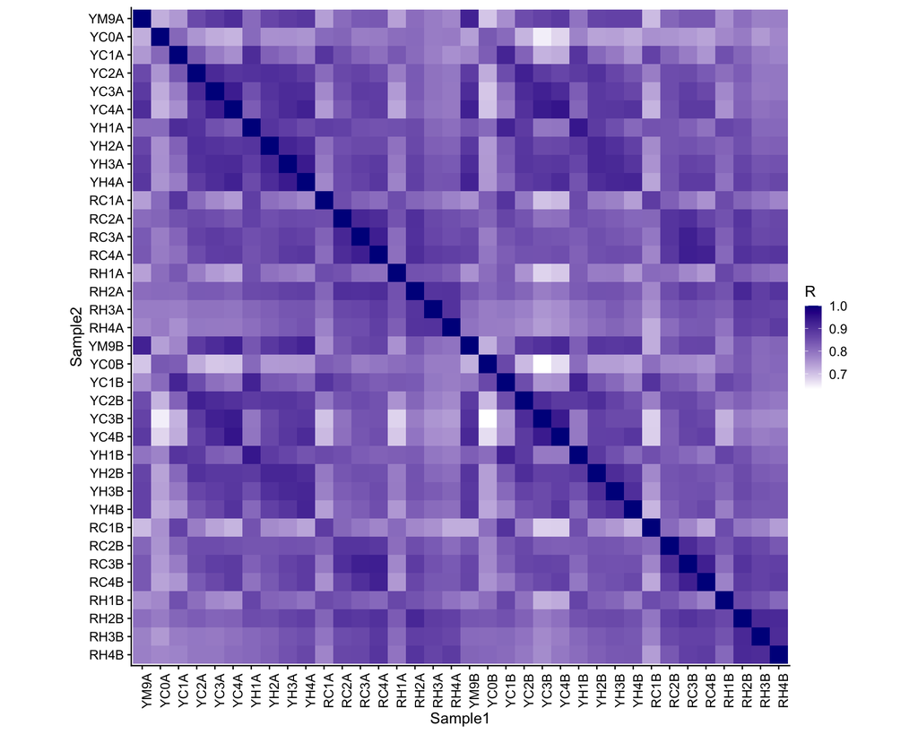

```r
cordf <-
  counts_all %>%
  magrittr::add(1) %>%
  log10() %>%
  cor() %>%
  as.data.frame() %>%
  mutate(Sample1 = names(.)) %>%
  pivot_longer(cols = -Sample1,
               names_to = "Sample2",
               values_to = "R") %>%
  mutate(Sample1 = factor(Sample1, levels = Codelevels),
         Sample2 = factor(Sample2, levels = rev(Codelevels)))

ggplot(data = cordf, aes(x = Sample1, y = Sample2, fill = R)) +
  geom_tile() +
  coord_equal() +
  scale_fill_gradient(low = "white", high = "darkblue") +
  theme(axis.text.x = element_text(angle = 90))
```

# Normalize counts by regularized log (rlog) with DESeq2

The [rlog function from DESeq2](https://rdrr.io/bioc/DESeq2/man/rlog.html) “transforms the count data to the log2 scale in a way which minimizes differences between samples for rows with small counts, and which normalizes with respect to library size.”

## Construct DESeq dataset object

```r
dds_all <- DESeqDataSetFromMatrix(countData = counts_all,
                                  colData = sample_sheet_abbreviated,
                                  design = ~ Code)
```

# Do the rlog transformation

```r
rlog_all <- rlog(dds_all)
```

```
## rlog() may take a few minutes with 30 or more samples,
## vst() is a much faster transformation
```

```r
head(assay(rlog_all))
```

```
##                YM9A     YC0A     YC1A     YC2A     YC3A     YC4A     YH1A
## CNAG_00002 4.428174 3.392679 2.958078 4.545464 3.574238 3.442926 3.572652
## CNAG_00003 4.520224 6.158517 5.100916 5.221636 5.250659 5.334142 4.132195
## CNAG_00004 7.535274 7.549937 7.305993 6.935196 7.502778 7.281756 6.883680
## CNAG_00005 4.734151 4.443880 3.108445 3.924194 5.099756 5.592270 4.556956
## CNAG_00006 8.100429 7.849384 8.150222 7.556482 7.432730 7.215540 7.715174
## CNAG_00007 7.325679 7.818924 7.053218 7.359471 7.355356 7.390072 7.485507
##                YH2A     YH3A     YH4A     RC1A     RC2A     RC3A     RC4A
## CNAG_00002 3.319134 4.241056 4.902576 4.172068 5.172107 4.846893 4.072325
## CNAG_00003 4.343983 4.926897 5.088845 5.843404 4.534013 5.884301 5.672699
## CNAG_00004 6.290928 7.082746 7.234850 7.639099 7.968742 8.043467 7.829489
## CNAG_00005 5.776035 6.556164 6.080645 4.658172 3.674576 4.133310 4.876988
## CNAG_00006 7.666151 7.362702 7.690202 7.115743 8.035248 7.886817 7.827256
## CNAG_00007 7.198774 7.485492 7.632414 6.699544 6.832760 6.921557 7.109454
##                RH1A     RH2A     RH3A     RH4A     YM9B     YC0B     YC1B
## CNAG_00002 5.165074 5.224184 4.574697 3.435585 5.304970 3.652532 3.847603
## CNAG_00003 3.500412 5.666561 4.395073 4.226443 5.128716 5.623832 5.094080
## CNAG_00004 7.571848 7.433572 7.160594 7.011360 7.271338 7.768201 7.517963
## CNAG_00005 4.623856 5.407510 4.006223 5.078948 5.163963 5.433977 3.728740
## CNAG_00006 8.294800 7.706138 7.730528 7.667414 7.892313 8.163347 8.293813
## CNAG_00007 7.319036 7.015657 7.286469 7.144628 7.793487 7.508369 7.306215
##                YC2B     YC3B     YC4B     YH1B     YH2B     YH3B     YH4B
## CNAG_00002 4.039828 3.975559 3.921503 4.394835 3.548805 3.343313 3.984577
## CNAG_00003 3.707309 4.830175 5.074126 4.148158 3.744867 5.205792 5.115481
## CNAG_00004 7.027081 7.009827 7.404482 6.520080 6.253286 6.720443 6.779050
## CNAG_00005 3.617233 4.139185 5.220484 4.109059 5.905157 5.455939 5.898122
## CNAG_00006 7.551965 7.374775 7.382350 7.857006 7.746801 7.468602 7.253419
## CNAG_00007 7.307515 7.468565 7.764189 7.448808 7.180889 7.607899 7.798497
##                RC1B     RC2B     RC3B     RC4B     RH1B     RH2B     RH3B
## CNAG_00002 5.470851 4.571593 5.486824 4.448794 4.483184 5.477650 3.704322
## CNAG_00003 5.369105 6.304876 5.950576 5.788375 4.793678 5.119823 5.418655
## CNAG_00004 8.071843 7.645726 8.060855 7.943375 6.939235 7.839607 7.213562
## CNAG_00005 5.062476 3.150651 3.135142 3.760836 3.758912 5.142286 3.979251
## CNAG_00006 7.729522 7.944261 7.775988 7.295372 8.552872 7.749762 7.600368
## CNAG_00007 7.763143 7.064833 7.354836 7.348201 7.050754 6.810534 6.858513
##                RH4B
## CNAG_00002 3.939231
## CNAG_00003 5.443224
## CNAG_00004 7.019327
## CNAG_00005 5.826023
## CNAG_00006 7.811514
## CNAG_00007 6.756099
```

# Check reproducibility by principal component analysis (PCA) of rlog

## Calculate PCs from the rlog output

```r
# calculate principal components of rlog, after extracting from the dataset
pca_rlog <- rlog_all %>%
  assay() %>%
  t() %>%
  prcomp()

# convert principal components to data frame
pcdf_rlog <- bind_cols(
  as_tibble(colData(rlog_all)),
  as_tibble(pca_rlog$x)
)

pcdf_rlog
```

```
## # A tibble: 36 × 45
##    SampleID Code  Medium Temp   Time Rep   MedTempTime MediumTemp sizeFactor
##    <chr>    <fct> <chr>  <chr> <dbl> <chr> <chr>       <chr>           <dbl>
##  1 CW01     YM9A  YPD    30C     180 A     YM9         YPD 30C         0.661
##  2 CW02     YC0A  YPD    25C       0 A     YC0         YPD 5days       0.323
##  3 CW03     YC1A  YPD    25C      10 A     YC1         YPD 25C         0.595
##  4 CW04     YC2A  YPD    25C      30 A     YC2         YPD 25C         1.11
##  5 CW05     YC3A  YPD    25C      60 A     YC3         YPD 25C         1.91
##  6 CW06     YC4A  YPD    25C     120 A     YC4         YPD 25C         2.26
##  7 CW07     YH1A  YPD    37C      10 A     YH1         YPD 37C         1.78
##  8 CW08     YH2A  YPD    37C      30 A     YH2         YPD 37C         0.849
##  9 CW09     YH3A  YPD    37C      60 A     YH3         YPD 37C         1.85
## 10 CW10     YH4A  YPD    37C     120 A     YH4         YPD 37C         3.08
## # … with 26 more rows, and 36 more variables: PC1 <dbl>, PC2 <dbl>, PC3 <dbl>,
## #   PC4 <dbl>, PC5 <dbl>, PC6 <dbl>, PC7 <dbl>, PC8 <dbl>, PC9 <dbl>,
## #   PC10 <dbl>, PC11 <dbl>, PC12 <dbl>, PC13 <dbl>, PC14 <dbl>, PC15 <dbl>,
## #   PC16 <dbl>, PC17 <dbl>, PC18 <dbl>, PC19 <dbl>, PC20 <dbl>, PC21 <dbl>,
## #   PC22 <dbl>, PC23 <dbl>, PC24 <dbl>, PC25 <dbl>, PC26 <dbl>, PC27 <dbl>,
## #   PC28 <dbl>, PC29 <dbl>, PC30 <dbl>, PC31 <dbl>, PC32 <dbl>, PC33 <dbl>,
## #   PC34 <dbl>, PC35 <dbl>, PC36 <dbl>
```

## Calculate proportion of variance explained by each PC

```r
propvar_rlog_df <- tibble(
  PC = seq.int(1L, ncol(pca_rlog$x) ),
  tot_var = pca_rlog$sdev^2,
  prop_var = tot_var/sum(tot_var)
)

propvar_rlog_df
```

```
## # A tibble: 36 × 3
##       PC tot_var prop_var
##    <int>   <dbl>    <dbl>
##  1     1  1126.    0.325
##  2     2   588.    0.170
##  3     3   245.    0.0707
##  4     4   204.    0.0590
##  5     5   172.    0.0495
##  6     6   122.    0.0353
##  7     7    81.2   0.0234
##  8     8    70.2   0.0203
##  9     9    66.8   0.0193
## 10    10    63.4   0.0183
## # … with 26 more rows
```

## Plot PCA percentage variance explained to find how many PCs to pay attention to.

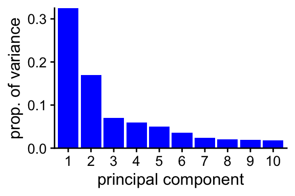

```r
plot_percentvar_rlog <-
  ggplot(data = propvar_rlog_df,
         aes(x = PC, y = prop_var)) +
  geom_col(fill = "blue") +
  scale_x_continuous("principal component",
                     limits = c(0.4,10.6),
                     # hack limits to include the bars and a little space.
                     breaks = 1L:10L,
                     expand = c(0,0)) +
  scale_y_continuous("prop. of variance", expand = c(0,0))
plot_percentvar_rlog
```

## Plot PC1 vs PC2 with default values

EDIT: the colour and other aesthetics may need to be further edited to highlight features of the data

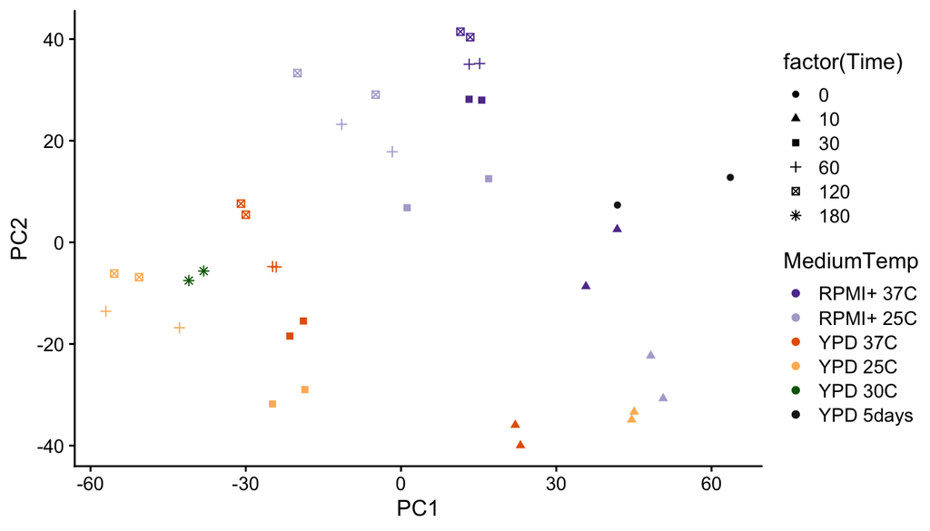

```r
ggplot(data = pcdf_rlog,
       aes(colour = MediumTemp, shape = factor(Time))
       ) +
  geom_point(aes(x = PC1, y = PC2)) +
  scale_colour_manual(# purpleorange
    values = c("RPMI+ 37C" = "#5e3c99",
               "RPMI+ 25C" = "#b2abd2",
               "YPD 37C" = "#e66101",
               "YPD 25C" = "#fdb863",
               "YPD 30C" = "darkgreen",
               "YPD 5days" = "grey10"))
```

Overall this argues that the biological replicates are clustering together in PC space.

## Plot PC1 vs PC2, 3, 4, also with default values

[figure not shown]

```r
# This could be wraped in a function
pc_baseplot <-
  ggplot(data = pcdf_rlog,
         aes(colour = MediumTemp,
             label = Time)
  ) +
  geom_hline(yintercept = 0, size = 0.5, colour = "grey80") +
  geom_vline(xintercept = 0, size = 0.5, colour = "grey80") +
  theme(legend.position = "none") +
  scale_colour_manual(# purpleorange
    "Medium, Temperature",
    values = c("RPMI+ 37C" = "#5e3c99",
               "RPMI+ 25C" = "#b2abd2",
               "YPD 37C" = "#e66101",
               "YPD 25C" = "#fdb863",
               "YPD 30C" = "darkgreen",
               "YPD 5days" = "grey10"),
    labels = c("RPMI+ 37C" = "RPMI+ 37°C",
               "RPMI+ 25C" = "RPMI+ 37°C",
               "YPD 37C" = "YPD 37°C",
               "YPD 25C" = "YPD 25°C",
               "YPD 30C" = "YPD 25°C 180min",
               "YPD 5days" = "YPD 5 days stationary")) +
  coord_cartesian(clip = "off")

pcplot_12 <- pc_baseplot + geom_text(aes(x = PC1, y = PC2), key_glyph = "point")
pcplot_13 <- pc_baseplot + geom_text(aes(x = PC1, y = PC3))
pcplot_14 <- pc_baseplot + geom_text(aes(x = PC1, y = PC4))
pcplot_23 <- pc_baseplot + geom_text(aes(x = PC2, y = PC3))
pcplot_24 <- pc_baseplot + geom_text(aes(x = PC2, y = PC4))
pcplot_34 <- pc_baseplot + geom_text(aes(x = PC3, y = PC4))

pcplot_legend <-
  get_legend(pcplot_12 +
               theme(legend.position = "right",
                     legend.box.margin = margin(4, 5, 4, 40)))

plot_grid(pcplot_12, pcplot_legend, plot_percentvar_rlog,
          pcplot_13, pcplot_23, NULL,
          pcplot_14, pcplot_24, pcplot_34)
```

- PC1 vs PC2 Stationary phase (YC0A/B) cluster distinctly, and the 10min samples (with “1” in them) are all similar to each other but different from later timepoints.
- PC2 separates RPMI from YPD samples at later timepoints, looking at the left side of the PC1/PC2 plot.
- PC3 mostly separates temperature, with 25C (cold) at the top at 37C (hot) at the bottom.
- PC4 separates stationary phase (YC0A/B) from everything else.
- A better choice of colours and display might make this clearer.